# STAT_4870_Project

Waleed Abdulla

2025-04-17

#Simple/Multiple Lin Reg doesn’t count but can be used for comparison #PCA #AIC #BIC #Log Regression #QDA/LDA #kNN

New Libraries: fastDummies, patchwork

Libraries

```r
Bank <- read.csv("C:/Users/Panic/ML/appliedregression/bankmarketing/bank-full.csv", sep = ";")
#Bank <- read.csv("C:/Users/13147/Documents/bankmarketing/bank-full.csv", sep = ";")
Bank %>% tail()
```

```
##       age          job  marital education default balance housing loan
## 45206  25   technician   single secondary      no     505      no  yes
## 45207  51   technician  married  tertiary      no     825      no   no
## 45208  71      retired divorced   primary      no    1729      no   no
## 45209  72      retired  married secondary      no    5715      no   no
## 45210  57  blue-collar  married secondary      no     668      no   no
## 45211  37 entrepreneur  married secondary      no    2971      no   no
##         contact day month duration campaign pdays previous poutcome   y
## 45206  cellular  17   nov      386        2    -1        0  unknown yes
## 45207  cellular  17   nov      977        3    -1        0  unknown yes
## 45208  cellular  17   nov      456        2    -1        0  unknown yes
## 45209  cellular  17   nov     1127        5   184        3  success yes
## 45210 telephone  17   nov      508        4    -1        0  unknown  no
## 45211  cellular  17   nov      361        2   188       11    other  no
```

Step 1: What question are we trying to answer?

- Predict if the client will subscribe to a term deposit (variable y).
  - Find the key predictors
  - Create a good applied regression model.

Step 2: Clean our data.

Before creating indicator variables for our categorical predictors, we need to find outliers. With categorical predictors, outliers are based on the size of the variable relative to the size of the entire column. For example:

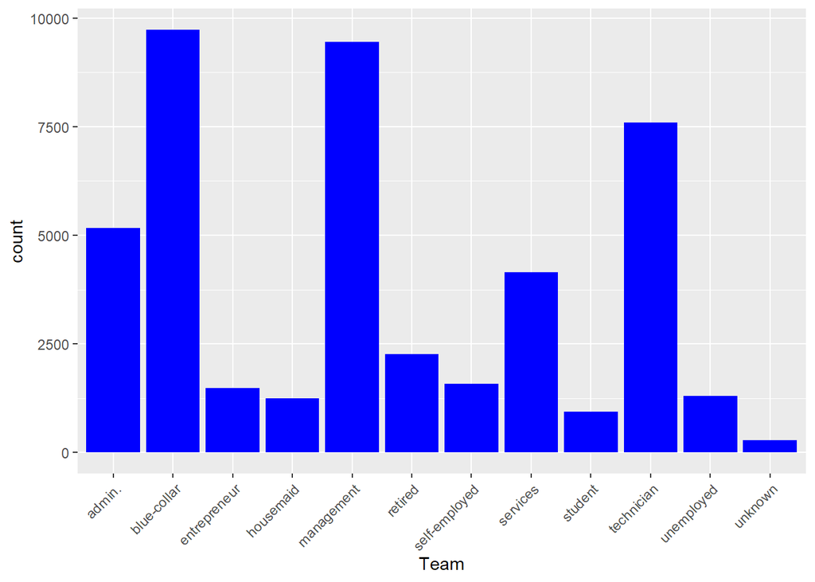

```r
Bank %>% ggplot(aes(x = job)) +
geom_bar(fill = "blue") + labs(x='Team') +
    theme(axis.text.x = element_text(angle = 45, hjust = 1))
```

The “unknown” variable is undoubtedly an outlier since it has a small count compared to the 40,000+ dataset. Let’s remove it and look at the following bar plot:

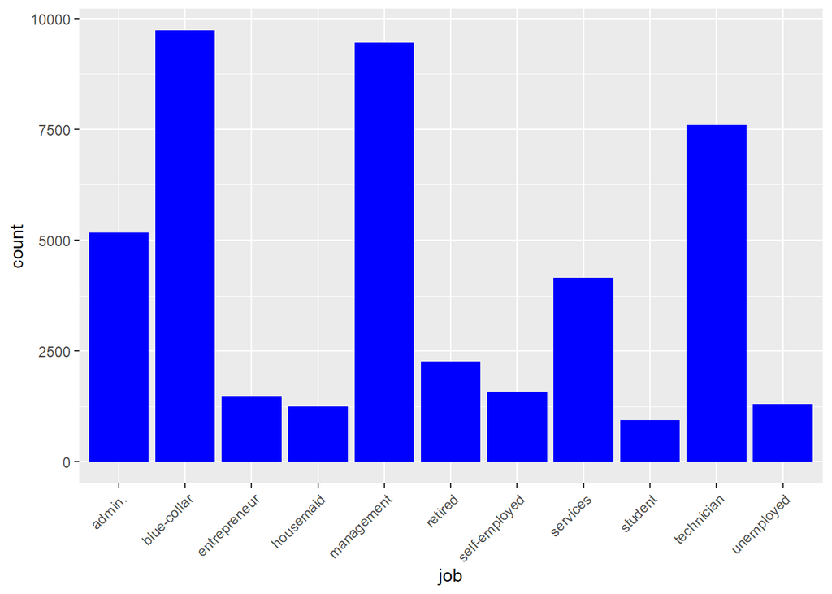

```r
Bank <- Bank %>% filter(job != "unknown")
Bank %>% ggplot(aes(x = job)) +
geom_bar(fill = "blue") +
  theme(axis.text.x = element_text(angle = 45, hjust = 1))
```

Now let’s look at the other categorical variables for potential outliers.

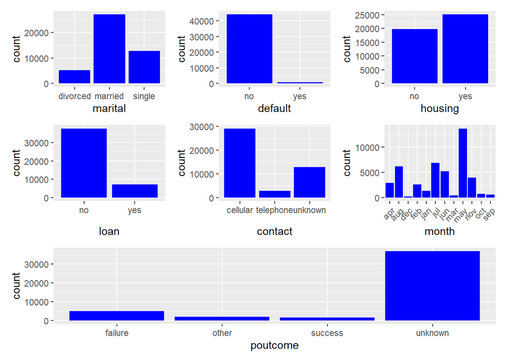

```r
p1 <- Bank %>% ggplot(aes(x = marital)) + geom_bar(fill = "blue")
p2 <- Bank %>% ggplot(aes(x = default)) + geom_bar(fill = "blue")
p3 <- Bank %>% ggplot(aes(x = housing)) + geom_bar(fill = "blue")
p4 <- Bank %>% ggplot(aes(x = loan)) + geom_bar(fill = "blue")
p5 <- Bank %>% ggplot(aes(x = contact)) + geom_bar(fill = "blue")
p6 <- Bank %>% ggplot(aes(x = month)) + geom_bar(fill = "blue") +
  theme(axis.text.x = element_text(angle = 45, hjust = 1))
p7 <- Bank %>% ggplot(aes(x = poutcome)) + geom_bar(fill = "blue")

# Arrange them in a grid
(p1 | p2 | p3) / (p4 | p5 | p6) / p7
```

There are no outliers in the marital variable. The default variable does have outliers, but we predict that whether or not someone defaulted on a loan highly affects whether or not they will subscribe to a term deposit, so we will keep it. There are no outliers in the housing, loan, or contact variables. Since months are temporal, removing outliers may affect the regression model. Finally, since the poutcome variable consists mostly of unknown, we’ll remove it since it provides no real information.

```r
Bank <- Bank %>% dplyr::select(-poutcome) %>% dummy_cols(select_columns = "y", remove_first_dummy = TRUE) %>% select(-y) %>% rename(y = y_yes)
```

Now we need to create indicator variables for our categorical predictors

```r
Bank %>% select_if(is.character) %>% head(3)
```

```
##            job marital education default housing loan contact month
## 1   management married  tertiary      no     yes   no unknown   may
## 2   technician  single secondary      no     yes   no unknown   may
## 3 entrepreneur married secondary      no     yes  yes unknown   may
```

There are 8 categorical indicators. Luckily, the fastDummies package automatically creates dummy variables for each categorical indicator. The package also allows us to remove the first dummy of every variable such that only n-1 dummies remain, avoiding multicollinearity issues in the future.

Since the “month” variable is an ordinal variable, we can change the months to 1 through 12.

```r
monthToNum <- c("jan" = 1, "feb" = 2, "mar" = 3, "apr" = 4, "may" = 5, "jun" = 6,
                "jul" = 7, "aug" = 8, "sep" = 9, "oct" = 10, "nov" = 11, "dec" = 12)

Bank <- Bank %>% mutate(month = as.integer(monthToNum[month])) %>% mutate(job = factor(job), marital = factor(marital), education = factor(education), default = factor(default), housing = factor(housing), loan = factor(loan), contact = factor(contact))

table(Bank$default, Bank$y)
```

```
##
##           0     1
##   no  38907  5203
##   yes   761    52
```

```r
table(Bank$job, Bank$y)
```

```
##
##                    0    1
##   admin.        4540  631
##   blue-collar   9024  708
##   entrepreneur  1364  123
##   housemaid     1131  109
##   management    8157 1301
##   retired       1748  516
##   self-employed 1392  187
##   services      3785  369
##   student        669  269
##   technician    6757  840
##   unemployed    1101  202
```

```r
table(Bank$housing, Bank$y)
```

```
##
##           0     1
##   no  16497  3322
##   yes 23171  1933
```

```r
table(Bank$loan, Bank$y)
```

```
##
##           0     1
##   no  32910  4773
##   yes  6758   482
```

```r
table(Bank$contact, Bank$y)
```

```
##
##                 0     1
##   cellular  24812  4342
##   telephone  2475   385
##   unknown   12381   528
```

```r
table(Bank$education, Bank$y)
```

```
##
##                 0     1
##   primary    6212   588
##   secondary 20690  2441
##   tertiary  11270  1992
##   unknown    1496   234
```

The *campaign* column is the number of contacts performed *during* this campaign and the *previous* column is the number of contacts performed *before* this campaign. Let’s combine both to get the total number of contacts. Since the “pdays” column relies on both columns, we’ll remove that too.

```r
Bank <- Bank %>% mutate(calls = campaign + previous) %>% dplyr::select(-c("previous", "pdays","campaign"))
```

The *day* column and the *month* column are linked, so we can remove the *day* column all together.

```r
Bank <- Bank %>% dplyr::select(-day)
#Bank <- Bank %>% filter(contact != "unknown", education != "unknown")
```

Final dataset (for now)

```r
Bank %>% head()
```

```
##   age          job marital education default balance housing loan contact month
## 1  58   management married  tertiary      no    2143     yes   no unknown     5
## 2  44   technician  single secondary      no      29     yes   no unknown     5
## 3  33 entrepreneur married secondary      no       2     yes  yes unknown     5
## 4  47  blue-collar married   unknown      no    1506     yes   no unknown     5
## 5  35   management married  tertiary      no     231     yes   no unknown     5
## 6  28   management  single  tertiary      no     447     yes  yes unknown     5
##   duration y calls
## 1      261 0     1
## 2      151 0     1
## 3       76 0     1
## 4       92 0     1
## 5      139 0     1
## 6      217 0     1
```

```r
Bank %>% count(y)
```

```
##   y     n
## 1 0 39668
## 2 1  5255
```

Now let’s look for obvious outliers within the quantitative variables:

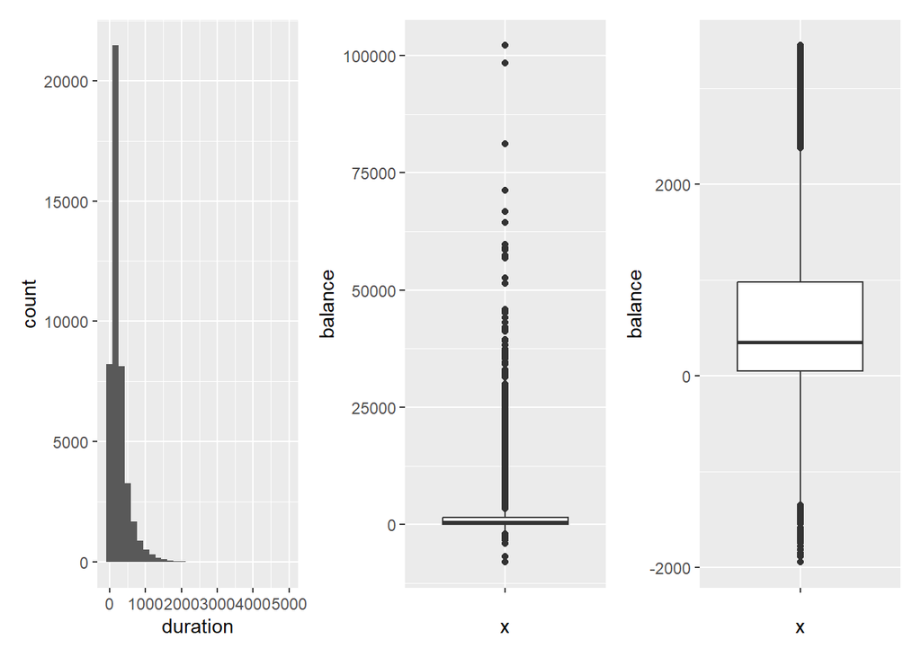

```r
p1 <- Bank %>% ggplot(aes(x = duration)) + geom_histogram()
p2 <- Bank %>% ggplot(aes(x = "", y = balance)) + geom_boxplot()
out <- boxplot.stats(Bank$balance)$out
Bank <- Bank %>% filter(!(balance %in% out))
p3 <- Bank %>% ggplot(aes(x = "", y = balance)) + geom_boxplot()
(p1 | p2 | p3)
```

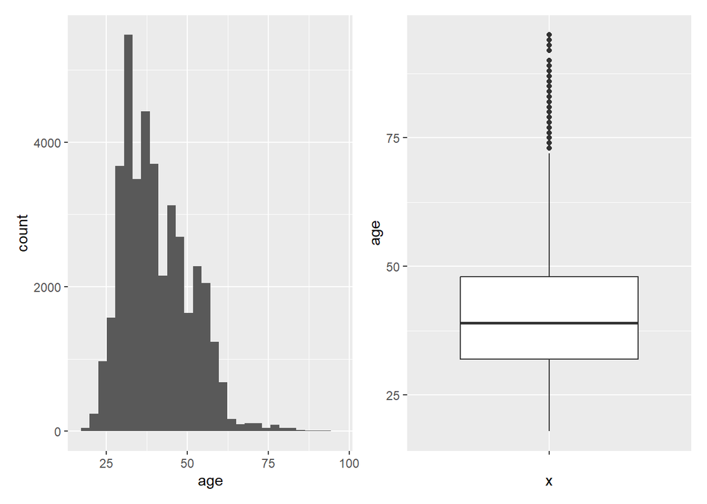

```r
p4 <- Bank %>% ggplot(aes(x=age)) + geom_histogram()
p5 <- Bank %>% ggplot(aes(x = "", y = age)) + geom_boxplot()
(p4 | p5)
```

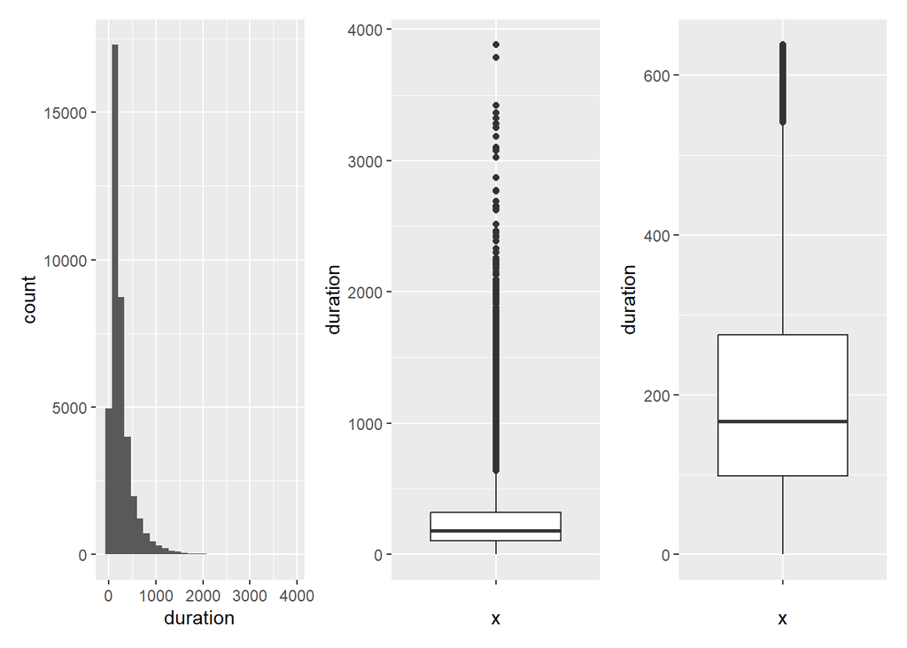

```r
p6 <- Bank %>% ggplot(aes(x = duration)) + geom_histogram()
p7 <- Bank %>% ggplot(aes(x = "", y = duration)) + geom_boxplot()
out <- boxplot.stats(Bank$duration)$out
Bank <- Bank %>% filter(!(duration %in% out))
p8 <- Bank %>% ggplot(aes(x = "", y = duration)) + geom_boxplot()
(p6 | p7 | p8)
```

Now let’s make a PCA dataset to reduce dimensionality and normalize it.

```r
numeric_vars <- Bank |>
  dplyr::select(age, balance, duration, month, calls)

Bank
```

[output not shown]

[output cut: 15372 more lines]

```r
numeric_scaled <- scale(numeric_vars)

pca_result <- prcomp(numeric_scaled, center = TRUE, scale. = TRUE)

summary(pca_result)
```

```
## Importance of components:
##                           PC1    PC2    PC3    PC4    PC5
## Standard deviation     1.0810 1.0557 0.9682 0.9521 0.9343
## Proportion of Variance 0.2337 0.2229 0.1875 0.1813 0.1746
## Cumulative Proportion  0.2337 0.4566 0.6441 0.8254 1.0000
```

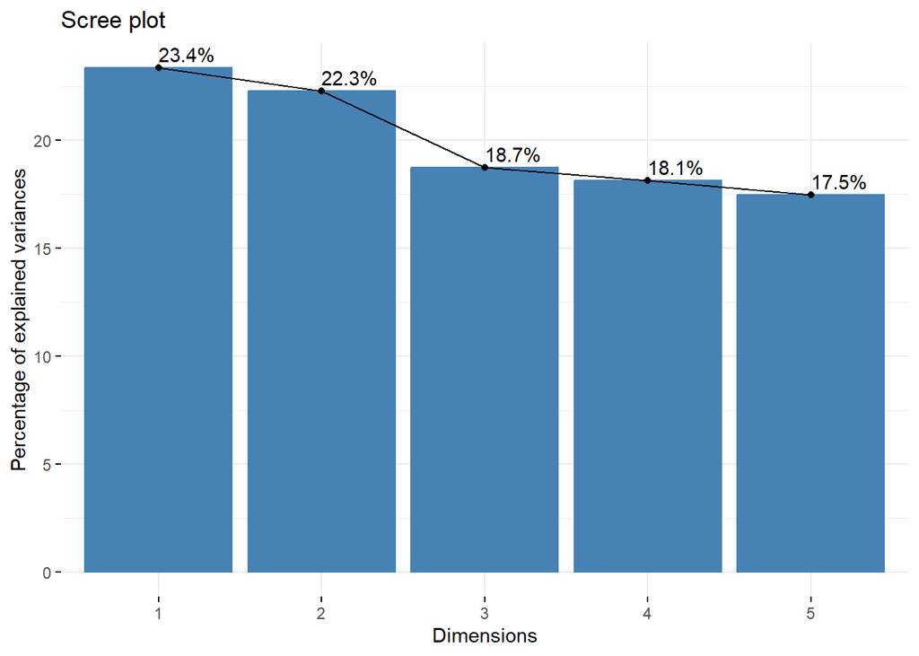

```r
library(factoextra)

#Show explained variance %
fviz_eig(pca_result, addlabels = TRUE)
```

```r
pca_components <- as.data.frame(pca_result$x[, 1:4])
colnames(pca_components) <- c("PC1", "PC2", "PC3","PC4")

BankPCA <- Bank |>
  dplyr::select(-age, -balance, -duration, -month, -calls) |>
  bind_cols(pca_components)

#BankPCA <- Bank |> filter(contact != "unknown", education != "unknown") %>%
#  dplyr::select(-age, -balance, -duration, -month) |>
#  bind_cols(pca_components)
```

Let’s split the data.

```r
set.seed(100)
split <- initial_split(Bank, prop = 0.7)
train <- training(split)
test <- testing(split)

trainx <- train %>% dplyr::select(-y)
trainy <- train %>% pull(y)
testx <- test %>% dplyr::select(-y)
testy <- test %>% pull(y)

dim(train)
```

```
## [1] 26149    13
```